# 第二回 リスト&演算子&条件分岐について

**開発環境**

- Python3.7

## リストについて

リストとは、複数のデータを格納することができるデータ型です

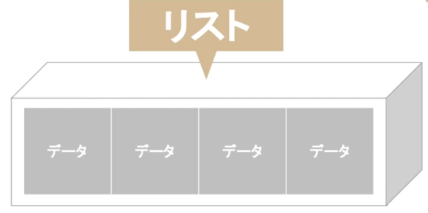

変数のレッスンでは、変数は『**箱**』と説明しました。

例えば、変数は1つのデータしか入れられない『**箱**』に対して、  
リストは複数のデータを入れることができる『**ロッカー**』です。

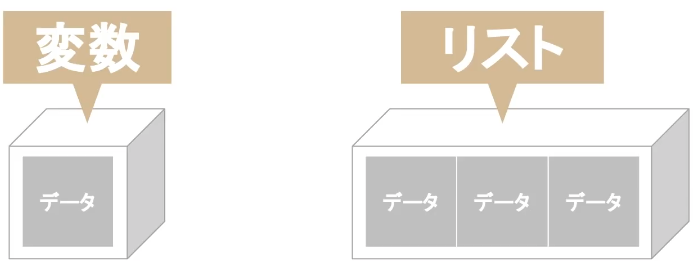

リストの1つ1つの箱のことを**`要素`**といいます。

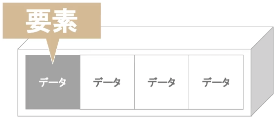

リストのそれぞれの要素には、場所の情報が割り当てられています。  
データが済んでいる住所のようなものです。

この住所には、**`インデックス`**という番号が割り当てられています。

一番左のインデックスは0から始まります。  
**1から始まるわけでわないので注意です**。

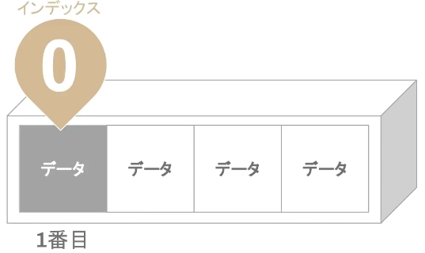

そのため、1番左のインデックスは『0』、2番目のインデックスは『1』、3番目のインデックスは『2』といったように、  
インデックスはリストが格納されている『**`順番-1`**』となっています。

それでは、リストの作り方をみていきましょう！

書き方は次の通りです。  
リストは各括弧`[ ]`を使って定義します。  
それぞれの要素は、カンマ(`,`)で区切ります

`変数 = [データ1, データ2, データ3,...]`

それでは、実際にソースコードで確認していきましょう。

下記コードは、aという変数に、`"sato","suzuki","takahashi"`という3つのデータが入ったリストを作るものです。

```python
a = ["sato", "suzuki", "takahashi"]

print(a)
```

作ったリストの要素にアクセスしてみましょう。

要素にアクセスするには**`インデックス`**を使います

変数の後に各括弧を付けます。  
各括弧の中にインデックスを指定することで、対応したリストの要素にアクセスできます。

```python
a = ["sato", "suzuki", "takahashi"]

print(a[0]) #aの1番目 >> sato
print(a[1]) #aの2番目 >> suzuki
print(a[2]) #aの3番目 >> takahashi
```

要素を変更してみましょう。

要素を指定して代入します。

リストの2番目の鈴木さんを田中さんに変更してみます。  
2番目なので各括弧に書くインデックスは`1`です。

```python
a = ["sato", "suzuki", "takahashi"]

a[1] = "tanaka" #リストaの2番目の鈴木さんを田中に変更

print(a[0]) #aの1番目 >> sato
print(a[1]) #aの2番目 >> tanaka
print(a[2]) #aの3番目 >> takahashi
```

リストの中にリストを入れることもできます。

リストの中にリストを入れる場合は、  
各括弧の中に各括弧を書き、そこに代入するデータを記述します。  
要素へのアクセスについては、各括弧を2回使用すれば良いです。

satoさんは、1つ目のリストの、1番目です。  
なので、0の0です。

suzukiさんは、1つ目のリストの、2番目です。  
なので、0の1です。

takahashiさんは、2つ目のリストの、1番目です。  
なので、1の0です。

tanakaさんは、2つ目のリストの、2番目です。  
なので、1の1です。

```python
a = [["sato", "suzuki"], ["takahashi", "tanaka"]]

print(a[0][0]) #1つ目の1番目は0の0 >> sato
print(a[0][1]) #1つ目の2番目は0の1 >> suzuki
print(a[1][0]) #1つ目の1番目は1の0 >> takahashi
print(a[1][1]) #1つ目の2番目は1の1 >> tanaka
```

## 演算子とは？

演算子とは、足し算、引き算などの四則演算や2つの大小を比較するときに使う記号のことです。

### ■算術演算子

算術演算子からみていきましょう。  
算術演算子とは、足し算、引き算、掛け算、割り算などをするための演算子です。

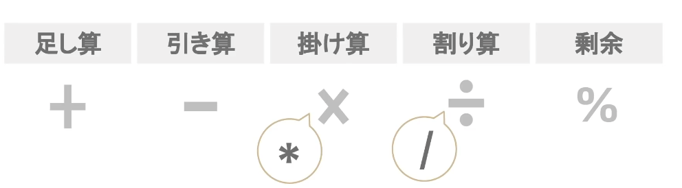

コードをみていきましょう。

xという変数に『10』、yという変数に『2』を代入。

このxとyの変数を使って、演算子の役割をみていきましょう。

```python
x = 10
y = 2

print(x + y) #足し算は + >> 12
print(x - y) #引き算は - >> 8
print(x * y) #掛け算は * (アスタリスク) >> 20
print(x / y) #割り算は /  >> 5
print(x % y) #余剰は % >> 0
```

### ■関係演算子

関係演算子とは、2つの値の関係が正しいか正しくないか判断させる演算子のことです。

例えば、『20』という数字は、『10』より大きいです。  
これを比較することができます。

20 > 10

関係演算子は、次のレッスンで学ぶ条件分岐の`if文`などでよく使います。

『10 > 2』という意味は、『10』は『2』より大きいという意味です。 → これは正しいです。  
2つの関係が正しいときには『**`True`**』が帰ってきます。

コードで試してみましょう。

xに10、yに2を代入します。

```python
x = 10
y = 2

print(x > y) # True
print(x < y) #False
```

以上、以下の場合は『>=』『<=』を使います。

```python
x = 10
y = 2
z = 10

print(x <= y) #xはyより小さいのでFalse
print(x >= z) #zはxと等価なのでTrue
```

次は等価についてみていきましょう。

**等価**とは、2つの値が**`等しい`**ということです。

等価はイコールが2つです。  
**`==`**

等価ではない場合は、エクスクラメーションマークにイコールです。  
**`!=`**

コードで試してみましょう。

```python
x = 10
y = 2

print(x == y) #10と2は同じではないので、False
print(x != y) #10と2は等価ではないので、True
```

### ■論理演算子

論理演算子とは、複数の条件を判断させる演算子のことです。

日本語で言うと『かつ』や『または』ということです。  
英語でいうとandとorです。

and条件は**`and`**を記述し、or条件は**`or`**を記述します。

『3』と『8』いう数字でみていきましょう。

例えば、  
『8』という数字は、5以上かつ10以下です。  
『3』という数字は、5以上かつ10以下ではないです。

コードで試してみましょう。

```python
# and条件について
x = 8
y = 3

print(x >= 5 and x <= 10) #8は5以上かつ10以下なのでTrue
print(y >= 5 and y <= 10) #3は５以上かつ10以下ではないのでFalse
```

```python
# or条件について
x = 8
y = 3

print(x == 3 or y == 3) #yが3なので、後ろの条件が一致します。　>> True
print(x == 1 or y == 1) #こちらはどちらの条件にも一致しない。 >> False
```

## 条件分岐について

条件分岐とは、条件に合致する場合は『処理A』、そうじゃないときは『処理B』ということができます。

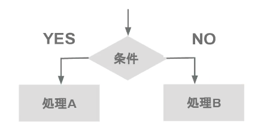

### ■if文について

条件分岐の代表例がif文です。  
Pythonでのきまりをみていきましょう。

まず`if`に続けて条件を書きます。  
コロンの次の行に『条件を満たしたときの処理』を書きます。  
この行は、インデントをひとつ右にずらして書きます。

```
if 条件:
    条件を満たしたときの処理
```

まずは、ageという変数の値が20歳以上なら大人という意味のadultと表示させる処理を書いてみましょう。

年齢という意味のageという変数に『22』という数値を代入しました。  
if分の条件にageが20以上と記述します。  
22は、20以上です。条件を満たすので、『adult』が表示されるはずです。

```python
age = 22

if age >= 20:
    print("adult")
```

次に、ageという変数に『18』を代入してみましょう。  
条件を満たさないので、なにも表示されないはずです。

```python
age = 18

if age >= 20:
    print("adult")
```

### ■if~else文

次に**`if~else`**文についてみていきましょう。

先ほどみたように、ただif文は条件を満たさない時に、  
処理されずプログラムが終了します。

一方、**`if~else`**文は、条件を満たさない時の処理を記述・実行することができます。  
**`if~else`**文のPythonのきまりをみていきましょう。

先程のif文のあとに、`else`と書きます。`else`の次の行もインデントを下げましょう。

そのあとに条件を満たさないときの処理を書きます。

```
if 条件A:
    条件Aを満たしたときの処理
else:
    条件を満たさないときの処理
```

コードを書いていきましょう。

ageに代入する数値を18とします。  
if文の条件は先ほどと同じように、20歳以上とします。

`else`以降に子供という意味の『child』を表示させ処理を書きます。

18は、20以上の条件を満たさないので、『child』が表示されるはずです。

```python
age = 18

if age >= 20:
    print("adult")
else:
    print("child")
```

### ■if~elif文

もう一つ条件を加えたい場合に使うのが、`elif`です。  
Pythonの決まりをみていきましょう。

先程の条件Aのif文のあとに、`elif`と書いて2つめの条件Bを書きます。  
次の行に、『条件Bを満たしたときの処理』を書きます。  
この行も、インデントをひとつ右にずらして書きます。

```
if 条件A:
    条件Aを満たしたときの処理
elif 条件B:
    条件Bを満たしたときの処理
else:
    条件を満たさないときの処理
```

それでは、コードを書いてみましょう。

20際以上なら『adult』、0歳なら『baby』、  
それ意外なら『child』というような記述をします。

**`elif`**のところに、ageが0だった場合の処理を記述します。

```python
age = 0

if age >= 20:
    print("adult") #20際以上なら: adult
elif age == 0:
    print("baby") #0歳なら:baby
else:
    print("child") #それ以外: child
```